# R 데이터 매니지먼트: base

[김진섭](https://github.com/jinseob2kim) 대표는 4월 2일(목) 부터 6회에 걸쳐, **[서울대병원 진단검사의학과](http://www.snuhlab.org/main/main.aspx) 의국원들의 통계분석 능력 함양을 위한 맞춤 교육** 이라는 주제로 R 교육을 진행할 예정입니다. 1주차 강의록을 미리 공유합니다.

## 시작하기 전에

**[R](https://www.r-project.org/)** 데이터 매니지먼트 방법은 크게 3 종류가 있다.

1. 원래의 **[R](https://www.r-project.org/)** 문법을 이용한 방법으로 **[과거 홈페이지](https://jinseob2kim.github.io/rbasic.html)**[^1]에 정리했었다.
2. **[tidyverse](https://www.tidyverse.org/)**는 직관적인 코드를 작성할 수 있는 점을 장점으로 원래의 **[R](https://www.r-project.org/)** 문법을 빠르게 대체하고 있다. **[본 블로그](https://blog.zarathu.com/posts/2019-01-03-rdatamanagement/)**에 정리 내용이 있다.
3. **[data.table](https://github.com/Rdatatable/data.table/wiki)** 패키지는 빠른 실행속도를 장점으로 **[tidyverse](https://www.tidyverse.org/)** 의 득세 속에서 살아남았으며, 역시 **[과거 홈페이지](https://jinseob2kim.github.io/radv1.html)**[^2]에 정리한 바 있다.

본 강의는 이중 첫 번째에 해당하며 2주차에 **[tidyverse](https://www.tidyverse.org/)** 를 다룰 것이다. **[data.table](https://github.com/Rdatatable/data.table/wiki)** 은 이번 교육에는 포함시키지 않았는데, R에 익숙해지면서 느린 속도가 점점 거슬린다면 **[data.table](https://github.com/Rdatatable/data.table/wiki)** 을 시작할 때이다.

실습은 클라우드 환경인 [RStudio cloud](https://rstudio.cloud/) 를 이용하여 진행한다. 회원가입 후, 아래를 따라 강의자료가 포함된 실습환경을 생성하자.

> 1. https://rstudio.cloud 회원 가입
> 2. https://rstudio.cloud/spaces/53975/join?access_code=kuFNlbt%2FbSj6DH%2FuppMdXzvU4e1EPrQNgNsFAQBf 들어가서 *“Join Space”* 클릭
> 3. 위쪽 *“Projects”* 클릭 후, *“New Project”* 를 눌러 *“New Project from Git Repo”* 를 선택 후, Repo 주소 **https://github.com/jinseob2kim/lecture-snuhlab** 입력.

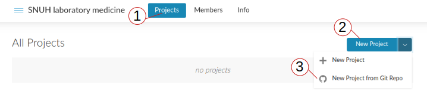

Project 생성

개인 PC에서 실습을 원한다면 http://www.r-project.org 와 https://rstudio.com/products/rstudio/download/#download 에서 **[R](https://www.r-project.org/)**과 **[RStudio](https://rstudio.com/)** 를 설치하자.

## 전체 강의 일정

| 회차 | 일시 | 주제 |
| --- | --- | --- |
| **1** | **4월 2일(목) 11-13시** | **R 데이터 매니지먼트 [기초](https://blog.zarathu.com/posts/2020-02-16-rdatamanagement-basic)** |
| 2 | 4월 14일(화) 11-13시 | R 데이터 매니지먼트 최근: [tidyverse](https://blog.zarathu.com/posts/2019-01-03-rdatamanagement/) |
| 3 | 4월 28일(화) 11-13시 | R 데이터 시각화: [ggplot2](https://evamaerey.github.io/ggplot_flipbook/ggplot_flipbook_xaringan.html) |
| 4 | 5월 12일(화) 11-13시 | [의학연구에서의 기술통계](https://blog.zarathu.com/posts/2018-11-24-basic-biostatistics/) |
| 5 | 5월 26일(화) 11-13시 | 회귀분석, 생존분석 |
| 6 | 6월 9일(화) 11-13시 | R로 논문쓰기: [rmarkdown](https://blog.zarathu.com/posts/2019-01-03-rmarkdown/) |

## *R* 기초연산 : 벡터(vector)

*R* 의 기본 연산단위는 벡터이며, `x <- c(1, 2, 3)` 은 1,2,3 으로 이루어진 길이 3인 벡터를 `x` 에 저장한다. 대입연산자는 `=` 와 `<-` 둘 다 가능하지만 함수의 인자로도 쓰이는 `=` 와 구별하기 위해 `<-` 를 권장한다. 자주 쓰는 연산을 실습하자.

```r
x <- c(1, 2, 3, 4, 5, 6)            ## vector of variable
y <- c(7, 8, 9, 10, 11, 12)
x + y
```

```
## [1]  8 10 12 14 16 18
```

```r
x * y
```

```
## [1]  7 16 27 40 55 72
```

```r
sqrt(x)                            ## root
```

```
## [1] 1.000000 1.414214 1.732051 2.000000 2.236068 2.449490
```

```r
sum(x)
```

```
## [1] 21
```

```r
diff(x)                            ## difference
```

```
## [1] 1 1 1 1 1
```

```r
mean(x)                            ## mean
```

```
## [1] 3.5
```

```r
var(x)                             ## variance
```

```
## [1] 3.5
```

```r
sd(x)                              ## standard deviation
```

```
## [1] 1.870829
```

```r
median(x)                          ## median
```

```
## [1] 3.5
```

```r
IQR(x)                             ## inter-quantile range
```

```
## [1] 2.5
```

```r
max(x)                             ## max value
```

```
## [1] 6
```

```r
which.max(x)                       ## order of max value
```

```
## [1] 6
```

```r
max(x, y)                          ## max value among x & y
```

```
## [1] 12
```

```r
length(x)
```

```
## [1] 6
```

`max(x, y)` 는 x, y 각각의 최대값이 아닌, **전체에서 최대인 값 1개**를 보여줌을 기억하자. 잠시 후 각각의 최대값 구하는 연습문제가 나온다.

벡터에서 특정 항목을 골라내려면 그것의 **위치** 혹은 **조건문**을 이용한다.

```r
x[2]                               ## 2 번째
```

```
## [1] 2
```

```r
x[-2]                              ## 2 번째만 빼고
```

```
## [1] 1 3 4 5 6
```

```r
x[1:3]                             ## 1-3 번째
```

```
## [1] 1 2 3
```

```r
x[c(1, 2, 3)]                      ## 동일
```

```
## [1] 1 2 3
```

```r
x[c(1, 3, 4, 5, 6)]                ## 1, 3, 4, 5, 6  번째
```

```
## [1] 1 3 4 5 6
```

```r
x >= 4                             ## 각 항목이 4 이상인지 TRUE/FALSE
```

```
## [1] FALSE FALSE FALSE  TRUE  TRUE  TRUE
```

```r
sum(x >= 4)                        ## TRUE 1, FALSE 0 인식
```

```
## [1] 3
```

```r
x[x >= 4]                          ## TRUE 인 것들만, 즉 4 이상인 것들
```

```
## [1] 4 5 6
```

```r
sum(x[x >= 4])                     ## 4 이상인 것들만 더하기.
```

```
## [1] 15
```

```r
x %in% c(1, 3, 5)                  ## 1, 3, 5 중 하나에 속하는지 TRUE/FALSE
```

```
## [1]  TRUE FALSE  TRUE FALSE  TRUE FALSE
```

```r
x[x %in% c(1, 3, 5)]
```

```
## [1] 1 3 5
```

### 벡터만들기

`seq` 로 일정 간격인, `rep` 로 항목들이 반복되는 벡터를 만들 수 있다.

```r
v1 <- seq(-5, 5, by = .2); v1             ## Sequence
```

```
##  [1] -5.0 -4.8 -4.6 -4.4 -4.2 -4.0 -3.8 -3.6 -3.4 -3.2 -3.0 -2.8 -2.6 -2.4 -2.2
## [16] -2.0 -1.8 -1.6 -1.4 -1.2 -1.0 -0.8 -0.6 -0.4 -0.2  0.0  0.2  0.4  0.6  0.8
## [31]  1.0  1.2  1.4  1.6  1.8  2.0  2.2  2.4  2.6  2.8  3.0  3.2  3.4  3.6  3.8
## [46]  4.0  4.2  4.4  4.6  4.8  5.0
```

```r
v2 <- rep(1, 3); v2                       ## Repeat
```

```
## [1] 1 1 1
```

```r
v3 <- rep(c(1, 2, 3), 2); v3              ## Repeat for vector
```

```
## [1] 1 2 3 1 2 3
```

```r
v4 <- rep(c(1, 2, 3), each = 2); v4       ## Repeat for vector : each
```

```
## [1] 1 1 2 2 3 3
```

### `for`, `if/else`, `ifelse` 문

`for` loop 는 같은 작업을 반복할 때 이용하며 `while` 도 비슷한 의미이다. 예시를 통해 배워보자.

```r
for (i in 1:3){
  print(i)
}
```

```
## [1] 1
## [1] 2
## [1] 3
```

```r
i <- 0
for (j in c(1, 2, 4, 5, 6)){
  i <- i + j
}
i
```

```
## [1] 18
```

`if` 와 `else` 는 조건문을 다룬다. **`else` 나 `else if` 문은 선행 조건문의 마지막과 같은 줄**이어야 함을 기억하자.

```r
x <- 5
if (x >= 3 ){
  x <- x + 3
}
x
```

```
## [1] 8
```

```r
x <- 5
if (x >= 10){
  print("High")
} else if (x >= 5){
  print("Medium")
} else {
  print("Low")
}                                          ## else if, else 주의: 반드시 } 와 같은 줄에 위치하도록.
```

```
## [1] "Medium"
```

`ifelse` 는 **벡터화**된 `if/else` 문으로 벡터의 각 항목마다 조건문을 적용하는데, 엑셀의 `if` 문과 비슷하다.

```r
x <- 1:6
y <- ifelse(x >= 4, "Yes", "No")           ## ifelse (조건,참일때,거짓일때)
y
```

```
## [1] "No"  "No"  "No"  "Yes" "Yes" "Yes"
```

### 함수 만들기

막 **R**을 배우는 단계에서는 함수를 만들어 쓸 일이 거의 없겠지만, 결측치 포함된 데이터에서 평균이나 분산을 구할 때 귀찮을 수 있다. **R**은 결측치가 하나라도 포함되면 평균값, 분산값으로 `NA`를 출력하기 때문이다. 이를 해결하기 위해서라도 아래처럼 기초 함수 만드는 법은 알고 있는 것이 좋다.

```r
x <- c(1:10, 12, 13, NA, NA, 15, 17)      ## 결측치가 포함되어 있다면..
mean(x)
```

```
## [1] NA
```

```r
mean0 <- function(x){
  mean(x, na.rm = T)
}                                         ## mean함수의 na.rm 옵션을 TRUE로 바꿈. default는 F
mean0 <- function(x){mean(x, na.rm = T)}  ## 한줄에 쓸 수도 있다.
mean0(x)
```

```
## [1] 8
```

둘 이상의 변수를 포함한 함수도 다음과 같이 만들 수 있다.

```r
twomean <- function(x1, x2){
  a <- (x1 + x2)/2
  a
}
twomean(4, 6)
```

```
## [1] 5
```

### Apply 문 : `apply`, `sapply`, `lapply`

벡터를 다루는 연산을 잘 활용하면, 벡터의 각 항목에 대해 `for` loop 을 쓰는 것보다 간편하게 코드를 작성할 수 있다. 행렬에서 행마다 평균을 구하는 예를 살펴보자.

```r
mat <- matrix(1:20, nrow = 4, byrow = T)   ## 4행 5열, byrow = T : 행부터 채운다.
mat
```

```
##      [,1] [,2] [,3] [,4] [,5]
## [1,]    1    2    3    4    5
## [2,]    6    7    8    9   10
## [3,]   11   12   13   14   15
## [4,]   16   17   18   19   20
```

모든 행에 대해 `for` loop 을 이용, 평균을 구하여 저장하는 코드는 아래와 같다.

```r
out <- NULL                                ## 빈 벡터, 여기에 하나씩 붙여넣는다.
for (i in 1:nrow(mat)){
  out <- c(out, mean(mat[i, ]))
}
out
```

```
## [1]  3  8 13 18
```

처음에 빈 벡터를 만들고 여기에 결과를 붙여가는 모습이 번거로워 보인다. `sapply` 또는 `lapply` 를 사용하면 행 또는 열 단위 연산을 간단히 수행할 수 있다.

```r
sapply(1:nrow(mat), function(x){mean(mat[x, ])})             ## Return vector
```

```
## [1]  3  8 13 18
```

```r
lapply(1:nrow(mat), function(x){mean(mat[x, ])})             ## Return list type
```

```
## [[1]]
## [1] 3
##
## [[2]]
## [1] 8
##
## [[3]]
## [1] 13
##
## [[4]]
## [1] 18
```

```r
unlist(lapply(1:nrow(mat), function(x){mean(mat[x, ])}))     ## Same to sapply
```

```
## [1]  3  8 13 18
```

처음에 빈 벡터를 만들고, 이어붙이는 과정이 생략되어 간단한 코드가 되었다. **list** 는 벡터보다 상위개념으로 모든 것을 담을 수 있는 큰 그릇에 비유할 수 있는데, 본 강의에서는 `unlist` 를 취하면 벡터나 행렬을 얻게 된다는 정도만 언급하고 넘어가겠다. 사실 행렬의 행/열 단위 연산은 `apply` 혹은 `row***`, `col***` 시리즈의 함수가 따로 있어, 더 간단히 이용할 수 있다.

```r
apply(mat, 1, mean)                                          ## 1: 행
```

```
## [1]  3  8 13 18
```

```r
rowMeans(mat)                                                ## 동일
```

```
## [1]  3  8 13 18
```

```r
rowSums(mat)                                                 ## 행별로 합
```

```
## [1] 15 40 65 90
```

```r
apply(mat, 2, mean)                                          ## 2: 열
```

```
## [1]  8.5  9.5 10.5 11.5 12.5
```

```r
colMeans(mat)                                                ## 열별로 합
```

```
## [1]  8.5  9.5 10.5 11.5 12.5
```

#### 연습문제 1

`sapply`나 `lapply`를 이용하여, 아래 두 벡터의 최대값을 각각 구하여라.

```r
x <- 1:6
y <- 7:12
```

**정답 보기**

```r
lapply(list(x, y), max)
```

```
## [[1]]
## [1] 6
##
## [[2]]
## [1] 12
```

```r
  sapply(list(x, y), max)
```

```
## [1]  6 12
```

멀티코어 병렬연산으로 `apply` 를 빠르게 수행할 수도 있는데 본 강의에서는 생략한다. 궁금하신 분은 [과거 정리 내용](https://jinseob2kim.github.io/rbasic.html#apply_%EB%AC%B8_:_apply,_sapply,_lapply) 을 참고하기 바란다.

## 데이터 불러와서 작업하기

이제부터는 실제 데이터를 읽어서 그 데이터를 매니징 하는 방법을 배워보도록 하겠다.

### 데이터 불러오기, 저장하기

데이터를 불러오기 전에 미리 디렉토리를 지정하면 그 다음부터는 편하게 읽고 쓸 수 있다.

```r
getwd()                                                     ## 현재 디렉토리
setwd("data")                                               ## 디렉토리 설정
## 동일
setwd("/cloud/project/data")
getwd()
```

폴더 구분을 **/** 로 해야 한다는 점을 명심하자 (`\\` 도 가능). **R** 은 유닉스 기반이기 때문이다. 이제 실습 데이터를 읽어볼텐데, 가급적이면 데이터 포맷은 `csv`로 만드는 것을 추천한다. 콤마로 분리된 가장 간단한 형태로, 용량도 작고 어떤 소프트웨어 에서도 읽을 수 있기 때문이다. 물론 Excel, SPSS, SAS 파일도 읽을 수 있는데, 변수명이나 값에 한글이 있으면 encoding 에러가 생길 수 있으므로 미리 처리하자.

```r
ex <- read.csv("example_g1e.csv")
head(ex)
```

URL 링크를 이용할 수도 있다.

```r
ex <- read.csv("https://raw.githubusercontent.com/jinseob2kim/lecture-snuhlab/master/data/example_g1e.csv")
```

| EXMD_BZ_YYYY | RN_INDI | HME_YYYYMM | Q_PHX_DX_STK | Q_PHX_DX_HTDZ | Q_PHX_DX_HTN | Q_PHX_DX_DM | Q_PHX_DX_DLD | Q_PHX_DX_PTB | Q_HBV_AG | Q_SMK_YN | Q_DRK_FRQ_V09N | HGHT | WGHT | WSTC | BMI | VA_LT | VA_RT | BP_SYS | BP_DIA | URN_PROT | HGB | FBS | TOT_CHOL | TG | HDL | LDL | CRTN | SGOT | SGPT | … |
| --- | --- | --- | --- | --- | --- | --- | --- | --- | --- | --- | --- | --- | --- | --- | --- | --- | --- | --- | --- | --- | --- | --- | --- | --- | --- | --- | --- | --- | --- | --- |
| 2009 | 562083 | 200909 | 0 | 0 | 1 | 0 | 0 | NA | 3 | 1 | 0 | 144 | 61 | 90 | 29.4 | 0.7 | 0.8 | 120 | 80 | 1 | 12.6 | 117 | 264 | 128 | 60 | 179 | 0.9 | 25 | 20 | … |
| 2009 | 334536 | 200911 | 0 | 0 | 0 | 0 | 0 | NA | 2 | 1 | 0 | 162 | 51 | 63 | 19.4 | 0.8 | 1.0 | 120 | 80 | 1 | 13.8 | 96 | 169 | 92 | 70 | 80 | 0.9 | 18 | 15 | … |
| 2009 | 911867 | 200903 | 0 | 0 | 0 | 0 | 0 | NA | 3 | 1 | 0 | 163 | 65 | 82 | 24.5 | 0.7 | 0.6 | 130 | 80 | 1 | 15.0 | 118 | 216 | 132 | 55 | 134 | 0.8 | 26 | 30 | … |
| 2009 | 183321 | 200908 | NA | NA | NA | NA | NA | NA | 3 | 1 | 0 | 152 | 51 | 70 | 22.1 | 0.8 | 0.9 | 101 | 62 | 1 | 13.1 | 90 | 199 | 100 | 65 | 114 | 0.9 | 18 | 14 | … |
| 2009 | 942671 | 200909 | NA | NA | NA | NA | NA | NA | 3 | 1 | 0 | 159 | 50 | 73 | 19.8 | 0.7 | 0.8 | 132 | 78 | 1 | 13.0 | 92 | 162 | 58 | 40 | 111 | 0.9 | 24 | 23 | … |
| 2009 | 979358 | 200912 | NA | NA | NA | NA | NA | NA | 2 | 1 | 0 | 157 | 55 | 73 | 22.3 | 1.5 | 1.5 | 110 | 70 | 1 | 11.9 | 100 | 192 | 109 | 53 | 117 | 0.7 | 15 | 12 | … |

Excel 파일은 **[readxl](https://readxl.tidyverse.org/)**, SAS나 SPSS는 **[haven](https://haven.tidyverse.org/)** 패키지를 이용한다.

```r
#install.packages(c("readxl", "haven"))                    ## install packages
library(readxl)                                            ## for xlsx
ex.excel <- read_excel("example_g1e.xlsx", sheet = 1)      ## 1st sheet
library(haven)                                             ## for SAS/SPSS/STATA
ex.sas <- read_sas("example_g1e.sas7bdat")                 ## SAS
ex.spss <- read_sav("example_g1e.sav")                     ## SPSS
head(ex.spss)
```

아래와 같이 Excel, SAS, SPSS 데이터는 `read.csv` 와 형태가 좀 달라보인다. 이것은 최근 **R**에서 인기있는 **[tidyverse](https://www.tidyverse.org/)** 스타일의 데이터인데, 자세한 내용은 다음 강의에서 다룰 예정이니 일단 넘어가자.

[output not shown]

| EXMD_BZ_YYYY | RN_INDI | HME_YYYYMM | Q_PHX_DX_STK | Q_PHX_DX_HTDZ | Q_PHX_DX_HTN | Q_PHX_DX_DM | Q_PHX_DX_DLD | Q_PHX_DX_PTB | Q_HBV_AG | Q_SMK_YN | Q_DRK_FRQ_V09N | HGHT | WGHT | WSTC | BMI | VA_LT | VA_RT | BP_SYS | BP_DIA | URN_PROT | HGB | FBS | TOT_CHOL | TG | HDL | LDL | CRTN | SGOT | SGPT | … |
| --- | --- | --- | --- | --- | --- | --- | --- | --- | --- | --- | --- | --- | --- | --- | --- | --- | --- | --- | --- | --- | --- | --- | --- | --- | --- | --- | --- | --- | --- | --- |
| 2009 | 562083 | 200909 | 0 | 0 | 1 | 0 | 0 | NA | 3 | 1 | 0 | 144 | 61 | 90 | 29.4 | 0.7 | 0.8 | 120 | 80 | 1 | 12.6 | 117 | 264 | 128 | 60 | 179 | 0.9 | 25 | 20 | … |
| 2009 | 334536 | 200911 | 0 | 0 | 0 | 0 | 0 | NA | 2 | 1 | 0 | 162 | 51 | 63 | 19.4 | 0.8 | 1.0 | 120 | 80 | 1 | 13.8 | 96 | 169 | 92 | 70 | 80 | 0.9 | 18 | 15 | … |
| 2009 | 911867 | 200903 | 0 | 0 | 0 | 0 | 0 | NA | 3 | 1 | 0 | 163 | 65 | 82 | 24.5 | 0.7 | 0.6 | 130 | 80 | 1 | 15.0 | 118 | 216 | 132 | 55 | 134 | 0.8 | 26 | 30 | … |
| 2009 | 183321 | 200908 | NA | NA | NA | NA | NA | NA | 3 | 1 | 0 | 152 | 51 | 70 | 22.1 | 0.8 | 0.9 | 101 | 62 | 1 | 13.1 | 90 | 199 | 100 | 65 | 114 | 0.9 | 18 | 14 | … |
| 2009 | 942671 | 200909 | NA | NA | NA | NA | NA | NA | 3 | 1 | 0 | 159 | 50 | 73 | 19.8 | 0.7 | 0.8 | 132 | 78 | 1 | 13.0 | 92 | 162 | 58 | 40 | 111 | 0.9 | 24 | 23 | … |
| 2009 | 979358 | 200912 | NA | NA | NA | NA | NA | NA | 2 | 1 | 0 | 157 | 55 | 73 | 22.3 | 1.5 | 1.5 | 110 | 70 | 1 | 11.9 | 100 | 192 | 109 | 53 | 117 | 0.7 | 15 | 12 | … |

파일 저장은 `write.csv` 를 이용하며, 맨 왼쪽에 나타나는 행 넘버링을 빼려면 `row.names = F` 옵션을 추가한다.

```r
write.csv(ex, "example_g1e_ex.csv", row.names = F)
```

**[haven](https://haven.tidyverse.org/)** 패키지에서 `write_sas` 나 `write_sav` 도 가능하다.

```r
write_sas(ex.sas, "example_g1e_ex.sas7bdat")
write_sav(ex.spss, "example_g1e_ex.sav")
```

## 읽은 데이터 살펴보기

### 데이터 살펴보기

`head` 로 처음 6줄, `tail` 로 마지막 6줄을 볼 수 있다. 데이터 간단히 확인하려고 쓰인다.

```r
head(ex)                                                   ## 처음 6행
tail(ex)                                                   ## 마지막 6행
head(ex, 10)                                               ## 처음 10행
```

| EXMD_BZ_YYYY | RN_INDI | HME_YYYYMM | Q_PHX_DX_STK | Q_PHX_DX_HTDZ | Q_PHX_DX_HTN | Q_PHX_DX_DM | Q_PHX_DX_DLD | Q_PHX_DX_PTB | Q_HBV_AG | Q_SMK_YN | Q_DRK_FRQ_V09N | HGHT | WGHT | WSTC | BMI | VA_LT | VA_RT | BP_SYS | BP_DIA | URN_PROT | HGB | FBS | TOT_CHOL | TG | HDL | LDL | CRTN | SGOT | SGPT | … |
| --- | --- | --- | --- | --- | --- | --- | --- | --- | --- | --- | --- | --- | --- | --- | --- | --- | --- | --- | --- | --- | --- | --- | --- | --- | --- | --- | --- | --- | --- | --- |
| 2009 | 562083 | 200909 | 0 | 0 | 1 | 0 | 0 | NA | 3 | 1 | 0 | 144 | 61 | 90 | 29.4 | 0.7 | 0.8 | 120 | 80 | 1 | 12.6 | 117 | 264 | 128 | 60 | 179 | 0.9 | 25 | 20 | … |
| 2009 | 334536 | 200911 | 0 | 0 | 0 | 0 | 0 | NA | 2 | 1 | 0 | 162 | 51 | 63 | 19.4 | 0.8 | 1.0 | 120 | 80 | 1 | 13.8 | 96 | 169 | 92 | 70 | 80 | 0.9 | 18 | 15 | … |
| 2009 | 911867 | 200903 | 0 | 0 | 0 | 0 | 0 | NA | 3 | 1 | 0 | 163 | 65 | 82 | 24.5 | 0.7 | 0.6 | 130 | 80 | 1 | 15.0 | 118 | 216 | 132 | 55 | 134 | 0.8 | 26 | 30 | … |
| 2009 | 183321 | 200908 | NA | NA | NA | NA | NA | NA | 3 | 1 | 0 | 152 | 51 | 70 | 22.1 | 0.8 | 0.9 | 101 | 62 | 1 | 13.1 | 90 | 199 | 100 | 65 | 114 | 0.9 | 18 | 14 | … |
| 2009 | 942671 | 200909 | NA | NA | NA | NA | NA | NA | 3 | 1 | 0 | 159 | 50 | 73 | 19.8 | 0.7 | 0.8 | 132 | 78 | 1 | 13.0 | 92 | 162 | 58 | 40 | 111 | 0.9 | 24 | 23 | … |
| 2009 | 979358 | 200912 | NA | NA | NA | NA | NA | NA | 2 | 1 | 0 | 157 | 55 | 73 | 22.3 | 1.5 | 1.5 | 110 | 70 | 1 | 11.9 | 100 | 192 | 109 | 53 | 117 | 0.7 | 15 | 12 | … |
| 2009 | 554112 | 200911 | NA | NA | NA | NA | NA | NA | 2 | 1 | 0 | 160 | 56 | 67 | 21.9 | 1.5 | 1.5 | 119 | 78 | 1 | 11.2 | 84 | 152 | 38 | 43 | 101 | 0.8 | 8 | 6 | … |
| 2009 | 487160 | 200908 | NA | NA | NA | NA | NA | NA | 3 | 1 | 0 | 159 | 54 | 66 | 21.4 | 1.2 | 1.5 | 111 | 60 | 1 | 12.2 | 88 | 166 | 42 | 58 | 99 | 1.0 | 16 | 11 | … |
| 2009 | 793017 | 200906 | NA | NA | NA | NA | NA | NA | 3 | 1 | 0 | 156 | 53 | 67 | 21.8 | 1.2 | 1.0 | 138 | 72 | 1 | 11.0 | 74 | 155 | 86 | 52 | 85 | 0.6 | 15 | 13 | … |
| 2009 | 219397 | 200912 | 0 | 0 | 1 | 0 | 0 | NA | 3 | 1 | 0 | 146 | 48 | 78 | 22.5 | 1.5 | 1.5 | 138 | 84 | 1 | 12.8 | 107 | 178 | 87 | 35 | 125 | 0.7 | 21 | 21 | … |

`str` 은 `head` 와는 다른 방식으로 데이터를 확인한다. **int** 는 정수, **num** 은 실수형을 의미한다.

```r
str(ex)
```

```
## 'data.frame':    1644 obs. of  32 variables:
##  $ EXMD_BZ_YYYY  : int  2009 2009 2009 2009 2009 2009 2009 2009 2009 2009 ...
##  $ RN_INDI       : int  562083 334536 911867 183321 942671 979358 554112 487160 793017 219397 ...
##  $ HME_YYYYMM    : int  200909 200911 200903 200908 200909 200912 200911 200908 200906 200912 ...
##  $ Q_PHX_DX_STK  : int  0 0 0 NA NA NA NA NA NA 0 ...
##  $ Q_PHX_DX_HTDZ : int  0 0 0 NA NA NA NA NA NA 0 ...
##  $ Q_PHX_DX_HTN  : int  1 0 0 NA NA NA NA NA NA 1 ...
##  $ Q_PHX_DX_DM   : int  0 0 0 NA NA NA NA NA NA 0 ...
##  $ Q_PHX_DX_DLD  : int  0 0 0 NA NA NA NA NA NA 0 ...
##  $ Q_PHX_DX_PTB  : int  NA NA NA NA NA NA NA NA NA NA ...
##  $ Q_HBV_AG      : int  3 2 3 3 3 2 2 3 3 3 ...
##  $ Q_SMK_YN      : int  1 1 1 1 1 1 1 1 1 1 ...
##  $ Q_DRK_FRQ_V09N: int  0 0 0 0 0 0 0 0 0 0 ...
##  $ HGHT          : int  144 162 163 152 159 157 160 159 156 146 ...
##  $ WGHT          : int  61 51 65 51 50 55 56 54 53 48 ...
```

[output cut: 18 more lines]

`names` 로 변수들 이름을 확인할 수 있다. **공백이나 특수문자는 “.”** 로 바뀌고, 이름이 같은 변수들은 뒤에 숫자가 추가되어 구별된다. `read.csv(..., check.names = F)` 옵션으로 원래 이름을 유지할 수 있으나 에러의 원인이 되므로 추천하지 않는다.

```r
names(ex)
```

```
##  [1] "EXMD_BZ_YYYY"   "RN_INDI"        "HME_YYYYMM"     "Q_PHX_DX_STK"
##  [5] "Q_PHX_DX_HTDZ"  "Q_PHX_DX_HTN"   "Q_PHX_DX_DM"    "Q_PHX_DX_DLD"
##  [9] "Q_PHX_DX_PTB"   "Q_HBV_AG"       "Q_SMK_YN"       "Q_DRK_FRQ_V09N"
## [13] "HGHT"           "WGHT"           "WSTC"           "BMI"
## [17] "VA_LT"          "VA_RT"          "BP_SYS"         "BP_DIA"
## [21] "URN_PROT"       "HGB"            "FBS"            "TOT_CHOL"
## [25] "TG"             "HDL"            "LDL"            "CRTN"
## [29] "SGOT"           "SGPT"           "GGT"            "GFR"
```

샘플수, 변수 갯수는 `dim`, `nrow`, `ncol` 로 확인한다.

```r
dim(ex)                                                    ## row, column
```

```
## [1] 1644   32
```

```r
nrow(ex)                                                   ## row
```

```
## [1] 1644
```

```r
ncol(ex)                                                   ## column
```

```
## [1] 32
```

클래스는 `class`로 확인한다. `read.csv` 는 **data.frame**, Excel/SAS/SPSS 는 **tibble & `data.frame** 인데, **data.frame** 은 **행렬**이면서 데이터에 특화된 **list**, **tibble** 은 앞서 언급했던 **[tidyverse](https://www.tidyverse.org/)** 스타일의 **data.frame** 인 정도만 알고 넘어가자.

```r
class(ex)
```

```
## [1] "data.frame"
```

```r
class(ex.spss)
```

```
## [1] "tbl_df"     "tbl"        "data.frame"
```

`summary` 로 모든 변수들의 평균, 중위수, 결측치 등을 한 번에 확인할 수 있다. *R*은 결측치를 `NA` 로 표시하며, 안타깝지만 분산은 나오지 않는다.

```r
summary(ex)
```

```
##   EXMD_BZ_YYYY     RN_INDI          HME_YYYYMM      Q_PHX_DX_STK
##  Min.   :2009   Min.   :   2270   Min.   :200901   Min.   :0.0000
##  1st Qu.:2010   1st Qu.: 230726   1st Qu.:201011   1st Qu.:0.0000
##  Median :2012   Median : 487160   Median :201210   Median :0.0000
##  Mean   :2012   Mean   : 490782   Mean   :201216   Mean   :0.0112
##  3rd Qu.:2014   3rd Qu.: 726101   3rd Qu.:201406   3rd Qu.:0.0000
##  Max.   :2015   Max.   :1010623   Max.   :201512   Max.   :1.0000
##                                                    NA's   :573
##  Q_PHX_DX_HTDZ     Q_PHX_DX_HTN   Q_PHX_DX_DM      Q_PHX_DX_DLD
##  Min.   :0.0000   Min.   :0.00   Min.   :0.0000   Min.   :0.0000
##  1st Qu.:0.0000   1st Qu.:0.00   1st Qu.:0.0000   1st Qu.:0.0000
##  Median :0.0000   Median :0.00   Median :0.0000   Median :0.0000
##  Mean   :0.0241   Mean   :0.25   Mean   :0.0693   Mean   :0.0399
##  3rd Qu.:0.0000   3rd Qu.:0.25   3rd Qu.:0.0000   3rd Qu.:0.0000
##  Max.   :1.0000   Max.   :1.00   Max.   :1.0000   Max.   :1.0000
##  NA's   :566      NA's   :492    NA's   :547      NA's   :566
##   Q_PHX_DX_PTB       Q_HBV_AG        Q_SMK_YN     Q_DRK_FRQ_V09N
##  Min.   :0.0000   Min.   :1.000   Min.   :1.000   Min.   :0.000
##  1st Qu.:0.0000   1st Qu.:2.000   1st Qu.:1.000   1st Qu.:0.000
##  Median :0.0000   Median :2.000   Median :1.000   Median :1.000
##  Mean   :0.0276   Mean   :2.235   Mean   :1.632   Mean   :1.026
##  3rd Qu.:0.0000   3rd Qu.:3.000   3rd Qu.:2.000   3rd Qu.:2.000
##  Max.   :1.0000   Max.   :3.000   Max.   :3.000   Max.   :7.000
##  NA's   :703      NA's   :2       NA's   :2       NA's   :6
##       HGHT            WGHT            WSTC             BMI
##  Min.   :134.0   Min.   : 31.0   Min.   : 57.00   Min.   :12.30
##  1st Qu.:158.0   1st Qu.: 56.0   1st Qu.: 74.00   1st Qu.:21.50
##  Median :165.0   Median : 64.0   Median : 81.00   Median :23.70
##  Mean   :164.5   Mean   : 65.1   Mean   : 80.69   Mean   :23.92
##  3rd Qu.:171.0   3rd Qu.: 73.0   3rd Qu.: 87.00   3rd Qu.:26.20
##  Max.   :188.0   Max.   :118.0   Max.   :114.00   Max.   :37.20
##
##      VA_LT           VA_RT            BP_SYS          BP_DIA
##  Min.   :0.100   Min.   :0.1000   Min.   : 81.0   Min.   : 49.0
##  1st Qu.:0.800   1st Qu.:0.7000   1st Qu.:110.0   1st Qu.: 70.0
##  Median :1.000   Median :1.0000   Median :120.0   Median : 78.0
##  Mean   :0.984   Mean   :0.9792   Mean   :122.3   Mean   : 76.6
##  3rd Qu.:1.200   3rd Qu.:1.2000   3rd Qu.:130.0   3rd Qu.: 82.0
##  Max.   :9.900   Max.   :9.9000   Max.   :180.0   Max.   :120.0
##
```

[output cut: 9 more lines]

```
##  Min.   :  13.0   Min.   : 23.0   Min.   :  19.0   Min.   : 0.4000
##  1st Qu.:  72.0   1st Qu.: 46.0   1st Qu.:  90.0   1st Qu.: 0.8000
##  Median : 106.0   Median : 54.0   Median : 112.0   Median : 0.9000
##  Mean   : 134.9   Mean   : 55.9   Mean   : 118.7   Mean   : 0.9891
##  3rd Qu.: 163.0   3rd Qu.: 64.0   3rd Qu.: 134.0   3rd Qu.: 1.0000
##  Max.   :1210.0   Max.   :593.0   Max.   :8100.0   Max.   :16.5000
##                                   NA's   :16
##       SGOT            SGPT             GGT              GFR
##  Min.   :  6.0   Min.   :  3.00   Min.   :  6.00   Min.   :  3.00
##  1st Qu.: 19.0   1st Qu.: 15.00   1st Qu.: 16.00   1st Qu.: 76.00
##  Median : 23.0   Median : 20.00   Median : 24.50   Median : 87.00
##  Mean   : 25.6   Mean   : 25.98   Mean   : 36.34   Mean   : 89.74
##  3rd Qu.: 28.0   3rd Qu.: 30.00   3rd Qu.: 41.00   3rd Qu.:101.00
##  Max.   :459.0   Max.   :779.00   Max.   :408.00   Max.   :196.00
##                                                    NA's   :467
```

### 특정 변수 보기

**data.frame** 에서 특정변수는 **`$`** 를 이용, **데이터이름$변수이름** 로 확인할 수 있다. 앞서 언급했듯이 **data.frame** 은 행렬과 list의 성질도 갖고 있어 해당 스타일로도 가능하다.

```r
ex$EXMD_BZ_YYYY                                            ## data.frame style
ex[, "EXMD_BZ_YYYY"]                                       ## matrix style
ex[["EXMD_BZ_YYYY"]]                                       ## list style
ex[, 1]                                                    ## matrix style with order
ex[[1]]                                                    ## list style with order
```

2개 이상 변수선택은 행렬 스타일을 이용한다.

```r
ex[, c("EXMD_BZ_YYYY", "RN_INDI", "BMI")]                  ## matrix syle with names
ex[, c(1, 2, 16)]                                          ## matrix syle with names
ex[, names(ex)[c(1, 2, 16)]]                               ## same
```

| EXMD_BZ_YYYY | RN_INDI | BMI |
| --- | --- | --- |
| 2009 | 562083 | 29.4 |
| 2009 | 334536 | 19.4 |
| 2009 | 911867 | 24.5 |
| 2009 | 183321 | 22.1 |
| 2009 | 942671 | 19.8 |
| 2009 | 979358 | 22.3 |
| 2009 | 554112 | 21.9 |
| 2009 | 487160 | 21.4 |
| 2009 | 793017 | 21.8 |
| 2009 | 219397 | 22.5 |

[output cut: 1634 more lines]

특정 변수는 벡터형태로 나타나므로 처음에 다루었던 벡터다루기를 그대로 활용할 수 있다. 예를 들어 년도 변수인 `EXMD_BZ_YYYY`의 첫 50개만 확인하면 아래와 같다.

```r
ex$EXMD_BZ_YYYY[1:50]                                      ## data.frame style
ex[1:50, 1]                                                ## matrix style
ex[[1]][1:50]                                              ## list style
```

```
##  [1] 2009 2009 2009 2009 2009 2009 2009 2009 2009 2009 2009 2009 2009 2009 2009
## [16] 2009 2009 2009 2009 2009 2009 2009 2009 2009 2009 2009 2009 2009 2009 2009
## [31] 2009 2009 2009 2009 2009 2009 2009 2009 2009 2009 2009 2009 2009 2009 2009
## [46] 2009 2009 2009 2009 2009
```

`unique` 로 변수가 어떤 값들로 이루어져 있는지, `table` 로 해당 값들이 몇개씩 있는지 확인한다.

```r
unique(ex$EXMD_BZ_YYYY)                                   ## unique value
```

```
## [1] 2009 2010 2011 2012 2013 2014 2015
```

```r
length(unique(ex$EXMD_BZ_YYYY))                           ## number of unique value
```

```
## [1] 7
```

```r
table(ex$EXMD_BZ_YYYY)                                    ## table
```

```
##
## 2009 2010 2011 2012 2013 2014 2015
##  214  236  223  234  243  254  240
```

### 새로운 변수 만들기

연속형 변수인 **BMI** 에서 원하는 조건에 맞는 정보를 뽑아내는 연습을 해 보자.

```r
mean(ex$BMI)                                              ## mean
```

```
## [1] 23.92257
```

```r
BMI_cat <- (ex$BMI >= 25)                                 ## TRUE of FALSE
table(BMI_cat)
```

```
## BMI_cat
## FALSE  TRUE
##  1077   567
```

```r
rows <- which(ex$BMI >= 25)                               ## row numbers
head(rows)
```

```
## [1]  1 14 18 21 23 24
```

```r
values <- ex$BMI[ex$BMI >= 25]                            ## values
head(values)
```

```
## [1] 29.4 27.5 27.7 28.0 30.7 25.6
```

```r
length(values)
```

```
## [1] 567
```

```r
BMI_HGHT_and <- (ex$BMI >= 25 & ex$HGHT >= 175)              ## and
BMI_HGHT_or <- (ex$BMI >= 25 | ex$HGHT >= 175)               ## or
```

데이터에 새로운 변수로 추가하는 방법은 간단하다.

```r
ex$zero <- 0                                              ## variable with 0
ex$BMI_cat <- (ex$BMI >= 25)                              ## T/F
ex$BMI_cat <- as.integer(ex$BMI >= 25)                    ## 0, 1
ex$BMI_cat <- as.character(ex$BMI >= 25)                  ## "0", "1"
ex$BMI_cat <- ifelse(ex$BMI >= 25, "1", "0")              ## same
table(ex$BMI_cat)
```

```
##
##    0    1
## 1077  567
```

```r
ex[, "BMI_cat"] <- (ex$BMI >= 25)                         ## matrix style
ex[["BMI_cat"]] <- (ex$BMI >= 25)                         ## list style
```

### 변수 클래스 설정: 데이터 읽은 후 가장 먼저 해야할 것.

앞서 데이터의 클래스가 **data.frame** 임을 언급했었는데, 각 변수들도 자신의 클래스를 갖으며 대표적인 것이 **숫자형(numeric), 문자형(character), 팩터(factor)** 이다. 그 외 T/F 로 나타내는 **논리(logical)**, 날짜를 나타내는 **Date** 클래스가 있다. 숫자는 integer(정수), numeric(실수) 이 있는데, 전부 실수형(numeric)으로 해도 상관없어 설명은 생략한다. 범주형은 **character** 와 **factor** 두 종류가 있는데, 전자는 단순 문자인 반면 후자는 레벨(level) 이 있어 reference 나 순서를 설정할 수 있다. `read.csv` 로 읽으면 숫자는 int/num, **문자는 전부 factor** 가 기본값이므로, 숫자 변수 중 0/1 같은 것들은 직접 **factor** 로 바꿔줘야 한다. ID와 설문조사 변수를 범주형으로 바꿔보자.

```r
vars.cat <- c("RN_INDI", "Q_PHX_DX_STK", "Q_PHX_DX_HTDZ", "Q_PHX_DX_HTN", "Q_PHX_DX_DM", "Q_PHX_DX_DLD", "Q_PHX_DX_PTB",
              "Q_HBV_AG", "Q_SMK_YN", "Q_DRK_FRQ_V09N")
vars.cat <- names(ex)[c(2, 4:12)]                              ## same
vars.cat <- c("RN_INDI", grep("Q_", names(ex), value = T))     ## same: extract variables starting with "Q_"
vars.conti <- setdiff(names(ex), vars.cat)                     ## Exclude categorical variables
vars.conti <- names(ex)[!(names(ex) %in% vars.cat)]            ## same: !- not, %in%- including
for (vn in vars.cat){                                          ## for loop: as.factor
  ex[, vn] <- as.factor(ex[, vn])
}
for (vn in vars.conti){                                        ## for loop: as.numeric
  ex[, vn] <- as.numeric(ex[, vn])
}
summary(ex)
```

```
##   EXMD_BZ_YYYY     RN_INDI       HME_YYYYMM     Q_PHX_DX_STK Q_PHX_DX_HTDZ
##  Min.   :2009   4263   :   7   Min.   :200901   0   :1059    0   :1052
##  1st Qu.:2010   38967  :   7   1st Qu.:201011   1   :  12    1   :  26
##  Median :2012   56250  :   7   Median :201210   NA's: 573    NA's: 566
##  Mean   :2012   84322  :   7   Mean   :201216
##  3rd Qu.:2014   99917  :   7   3rd Qu.:201406
##  Max.   :2015   115809 :   7   Max.   :201512
##                 (Other):1602
##  Q_PHX_DX_HTN Q_PHX_DX_DM Q_PHX_DX_DLD Q_PHX_DX_PTB Q_HBV_AG    Q_SMK_YN
##  0   :864     0   :1021   0   :1035    0   :915     1   :  77   1   :995
##  1   :288     1   :  76   1   :  43    1   : 26     2   :1102   2   :256
##  NA's:492     NA's: 547   NA's: 566    NA's:703     3   : 463   3   :391
##                                                     NA's:   2   NA's:  2
##
##
##
##  Q_DRK_FRQ_V09N      HGHT            WGHT            WSTC
##  0      :805    Min.   :134.0   Min.   : 31.0   Min.   : 57.00
##  1      :379    1st Qu.:158.0   1st Qu.: 56.0   1st Qu.: 74.00
##  2      :249    Median :165.0   Median : 64.0   Median : 81.00
##  3      :121    Mean   :164.5   Mean   : 65.1   Mean   : 80.69
##  4      : 28    3rd Qu.:171.0   3rd Qu.: 73.0   3rd Qu.: 87.00
##  (Other): 56    Max.   :188.0   Max.   :118.0   Max.   :114.00
##  NA's   :  6
##       BMI            VA_LT           VA_RT            BP_SYS
##  Min.   :12.30   Min.   :0.100   Min.   :0.1000   Min.   : 81.0
##  1st Qu.:21.50   1st Qu.:0.800   1st Qu.:0.7000   1st Qu.:110.0
##  Median :23.70   Median :1.000   Median :1.0000   Median :120.0
##  Mean   :23.92   Mean   :0.984   Mean   :0.9792   Mean   :122.3
##  3rd Qu.:26.20   3rd Qu.:1.200   3rd Qu.:1.2000   3rd Qu.:130.0
##  Max.   :37.20   Max.   :9.900   Max.   :9.9000   Max.   :180.0
##
##      BP_DIA         URN_PROT          HGB             FBS
##  Min.   : 49.0   Min.   :1.000   Min.   : 5.90   Min.   : 61.00
##  1st Qu.: 70.0   1st Qu.:1.000   1st Qu.:12.90   1st Qu.: 86.00
##  Median : 78.0   Median :1.000   Median :14.10   Median : 94.00
##  Mean   : 76.6   Mean   :1.078   Mean   :14.11   Mean   : 97.23
##  3rd Qu.: 82.0   3rd Qu.:1.000   3rd Qu.:15.40   3rd Qu.:103.00
##  Max.   :120.0   Max.   :5.000   Max.   :18.30   Max.   :290.00
##                  NA's   :4
```

[output cut: 9 more lines]

```
##  Min.   : 0.4000   Min.   :  6.0   Min.   :  3.00   Min.   :  6.00
##  1st Qu.: 0.8000   1st Qu.: 19.0   1st Qu.: 15.00   1st Qu.: 16.00
##  Median : 0.9000   Median : 23.0   Median : 20.00   Median : 24.50
##  Mean   : 0.9891   Mean   : 25.6   Mean   : 25.98   Mean   : 36.34
##  3rd Qu.: 1.0000   3rd Qu.: 28.0   3rd Qu.: 30.00   3rd Qu.: 41.00
##  Max.   :16.5000   Max.   :459.0   Max.   :779.00   Max.   :408.00
##
##       GFR              zero      BMI_cat
##  Min.   :  3.00   Min.   :0   Min.   :0.0000
##  1st Qu.: 76.00   1st Qu.:0   1st Qu.:0.0000
##  Median : 87.00   Median :0   Median :0.0000
##  Mean   : 89.74   Mean   :0   Mean   :0.3449
##  3rd Qu.:101.00   3rd Qu.:0   3rd Qu.:1.0000
##  Max.   :196.00   Max.   :0   Max.   :1.0000
##  NA's   :467
```

`summary` 를 보면 설문조사 변수들이 처음과 달리 빈도로 요약됨을 알 수 있다. 한 가지 주의할 점은 **factor 를 numeric 으로 바로 바꾸면 안된다는 것이다**. 방금 factor 로 바꾼 **Q_PHX_DX_STK** 를 numeric 으로 바꿔서 테이블로 요약하면, 원래의 0/1 이 아닌 1/2로 바뀐다.

```r
table(
  as.numeric(ex$Q_PHX_DX_STK)
  )
```

```
##
##    1    2
## 1059   12
```

factor를 바로 바꾸면 원래 값이 아닌, factor에 내장된 레벨(순서값) 로 바뀌기 때문이다. 제대로 바꾸려면 아래처럼 **character** 로 먼저 바꿔준 후 숫자형을 적용해야 한다.

```r
table(
  as.numeric(as.character(ex$Q_PHX_DX_STK))
  )
```

```
##
##    0    1
## 1059   12
```

마지막으로 **Date** 클래스를 살펴보자. 검진년월 변수인 **HME_YYYYMM** 를 Date 로 바꿔 볼텐데, Date는 년/월/일 이 모두 필요하므로 일은 1로 통일하고 `paste` 로 붙이겠다.

```r
addDate <- paste(ex$HME_YYYYMM, "01", sep = "")                ## add day- use `paste`
ex$HME_YYYYMM <- as.Date(addDate, format = "%Y%m%d")           ## set format
head(ex$HME_YYYYMM)
```

```
## [1] "2009-09-01" "2009-11-01" "2009-03-01" "2009-08-01" "2009-09-01"
## [6] "2009-12-01"
```

```r
class(ex$HME_YYYYMM)
```

```
## [1] "Date"
```

### 결측치 다루기

변수 클래스만큼 중요한 것이 결측치 처리이다. 앞서 “함수만들기” 에서 봤듯이 결측치가 있으면 평균같은 기본적인 계산도 `na.rm = T` 옵션이 필요하다. 결측치가 있는 **LDL** 변수의 평균을 **연도별**로 구해보자. 그룹별 통계는 `tapply` 를 이용한다.

```r
tapply(ex$LDL, ex$EXMD_BZ_YYYY, mean)                          ## measure/group/function
```

| 2009 | 2010 | 2011 | 2012 | 2013 | 2014 | 2015 |
| --- | --- | --- | --- | --- | --- | --- |
| 150.9486 | NA | NA | NA | NA | NA | NA |

2009년만 결측치가 없고, 나머지는 결측치가 있어 평균값이 NA 로 나온다.`na.rm = T` 옵션으로 결측치를 제외하면 원하는 결과를 얻는다.

```r
tapply(ex$LDL, ex$EXMD_BZ_YYYY,
       function(x){
         mean(x, na.rm = T)
         })
```

```
##     2009     2010     2011     2012     2013     2014     2015
## 150.9486 112.9914 112.9450 117.5259 111.1577 116.5455 111.5294
```

더 큰 문제는, 대부분의 **R** 통계분석이 결측치를 갖는 샘플을 분석에서 제외한다는 점이다. 그래서 결측치를 신경쓰지 않고 분석하다보면, 원래 샘플 수와 분석에 이용된 샘플 수가 달라지는 문제가 생길 수 있다. **LDL**과 **HDL** 의 회귀분석 결과를 예로 살펴보자.

```r
summary(lm(LDL ~ HDL, data = ex))
```

```
##
## Call:
## lm(formula = LDL ~ HDL, data = ex)
##
## Residuals:
##    Min     1Q Median     3Q    Max
## -103.8  -28.2   -6.6   15.4 7974.7
##
## Coefficients:
##             Estimate Std. Error t value Pr(>|t|)
## (Intercept) 138.2747    15.2318   9.078   <2e-16 ***
## HDL          -0.3499     0.2570  -1.362    0.174
## ---
## Signif. codes:  0 '***' 0.001 '**' 0.01 '*' 0.05 '.' 0.1 ' ' 1
##
## Residual standard error: 201.9 on 1626 degrees of freedom
##   (16 observations deleted due to missingness)
## Multiple R-squared:  0.001139,   Adjusted R-squared:  0.0005244
## F-statistic: 1.854 on 1 and 1626 DF,  p-value: 0.1735
```

**“16 observations deleted due to missingness”** 라는 글자가 보일 것이다. **LDL** 이 결측인 16명은 분석에서 제외했다는 뜻이다.

#### 연습문제 2: 결측치 처리

결측치를 처리하는 제일 간단한 방법은 **“하나라도 결측치 있는 샘플은 제외”** 로, `na.omit` 함수를 이용하면 된다.

```r
ex.naomit <- na.omit(ex)
nrow(ex.naomit)
```

```
## [1] 620
```

1644 명에서 620 명으로 샘플 수가 줄어든 것을 확인할 수 있다. 필자는 보통 결측치 처리에 다음의 3가지 원칙을 적용한다.

1. 결측치 너무 많으면(예: 10% 이상) 그 변수는 **삭제**
2. 연속변수는 **중간값(median)**
3. 범주형변수는 **최빈값(mode)**

이제 문제이다. 아까 변수형을 정리한 **ex** 데이터에 위 3가지 원칙을 적용, 새로운 데이터 **ex.impute** 을 만들어 보아라. 단 최빈값 함수는 아래와 같이 `getmode` 로 주어진다.

```r
getmode <- function(v){
   uniqv <- unique(v)
   uniqv[which.max(tabulate(match(v, uniqv)))]
}
getmode(ex$Q_PHX_DX_STK)
```

```
## [1] 0
## Levels: 0 1
```

**정답 보기**

```r
vars.ok <- sapply(names(ex), function(v){sum(is.na(ex[, v])) < nrow(ex)/10})
ex.impute <- ex[, vars.ok]                                     ## only missing < 10%
for (v in names(ex.impute)){
  if (is.factor(ex.impute[, v])){                              ## or class(ex[, v]) == "factor"
    ex.impute[, v] <- ifelse(is.na(ex.impute[, v]),
                             getmode(ex.impute[, v]),
                             ex.impute[, v])
  } else if (is.numeric(ex[, v])){                             ## or class(ex[, v]) %in% c("integer", "numeric")
    ex.impute[, v] <- ifelse(is.na(ex.impute[, v]),
                             median(ex.impute[, v], na.rm = T),
                             ex.impute[, v])
  } else{                                                      ## when date
    ex.impute[, v]
  }
}
summary(ex.impute)
```

```
##   EXMD_BZ_YYYY     RN_INDI        HME_YYYYMM            Q_HBV_AG
##  Min.   :2009   Min.   :  1.0   Min.   :2009-01-01   Min.   :1.000
##  1st Qu.:2010   1st Qu.:133.8   1st Qu.:2010-11-01   1st Qu.:2.000
##  Median :2012   Median :275.0   Median :2012-10-01   Median :2.000
##  Mean   :2012   Mean   :272.7   Mean   :2012-08-31   Mean   :2.235
##  3rd Qu.:2014   3rd Qu.:405.2   3rd Qu.:2014-06-01   3rd Qu.:3.000
##  Max.   :2015   Max.   :547.0   Max.   :2015-12-01   Max.   :3.000
##     Q_SMK_YN     Q_DRK_FRQ_V09N       HGHT            WGHT
##  Min.   :1.000   Min.   :1.000   Min.   :134.0   Min.   : 31.0
##  1st Qu.:1.000   1st Qu.:1.000   1st Qu.:158.0   1st Qu.: 56.0
##  Median :1.000   Median :2.000   Median :165.0   Median : 64.0
##  Mean   :1.631   Mean   :2.023   Mean   :164.5   Mean   : 65.1
##  3rd Qu.:2.000   3rd Qu.:3.000   3rd Qu.:171.0   3rd Qu.: 73.0
##  Max.   :3.000   Max.   :8.000   Max.   :188.0   Max.   :118.0
##       WSTC             BMI            VA_LT           VA_RT
##  Min.   : 57.00   Min.   :12.30   Min.   :0.100   Min.   :0.1000
##  1st Qu.: 74.00   1st Qu.:21.50   1st Qu.:0.800   1st Qu.:0.7000
##  Median : 81.00   Median :23.70   Median :1.000   Median :1.0000
##  Mean   : 80.69   Mean   :23.92   Mean   :0.984   Mean   :0.9792
##  3rd Qu.: 87.00   3rd Qu.:26.20   3rd Qu.:1.200   3rd Qu.:1.2000
##  Max.   :114.00   Max.   :37.20   Max.   :9.900   Max.   :9.9000
##      BP_SYS          BP_DIA         URN_PROT          HGB
##  Min.   : 81.0   Min.   : 49.0   Min.   :1.000   Min.   : 5.90
##  1st Qu.:110.0   1st Qu.: 70.0   1st Qu.:1.000   1st Qu.:12.90
##  Median :120.0   Median : 78.0   Median :1.000   Median :14.10
##  Mean   :122.3   Mean   : 76.6   Mean   :1.078   Mean   :14.11
##  3rd Qu.:130.0   3rd Qu.: 82.0   3rd Qu.:1.000   3rd Qu.:15.40
##  Max.   :180.0   Max.   :120.0   Max.   :5.000   Max.   :18.30
##       FBS            TOT_CHOL           TG              HDL
##  Min.   : 61.00   Min.   : 68.0   Min.   :  13.0   Min.   : 23.0
##  1st Qu.: 86.00   1st Qu.:170.0   1st Qu.:  72.0   1st Qu.: 46.0
##  Median : 94.00   Median :193.0   Median : 106.0   Median : 54.0
##  Mean   : 97.23   Mean   :194.9   Mean   : 134.9   Mean   : 55.9
##  3rd Qu.:103.00   3rd Qu.:218.0   3rd Qu.: 163.0   3rd Qu.: 64.0
##  Max.   :290.00   Max.   :363.0   Max.   :1210.0   Max.   :593.0
##       LDL              CRTN              SGOT            SGPT
##  Min.   :  19.0   Min.   : 0.4000   Min.   :  6.0   Min.   :  3.00
##  1st Qu.:  90.0   1st Qu.: 0.8000   1st Qu.: 19.0   1st Qu.: 15.00
##  Median : 112.0   Median : 0.9000   Median : 23.0   Median : 20.00
##  Mean   : 118.6   Mean   : 0.9891   Mean   : 25.6   Mean   : 25.98
##  3rd Qu.: 134.0   3rd Qu.: 1.0000   3rd Qu.: 28.0   3rd Qu.: 30.00
##  Max.   :8100.0   Max.   :16.5000   Max.   :459.0   Max.   :779.00
##       GGT              zero      BMI_cat
##  Min.   :  6.00   Min.   :0   Min.   :0.0000
##  1st Qu.: 16.00   1st Qu.:0   1st Qu.:0.0000
##  Median : 24.50   Median :0   Median :0.0000
##  Mean   : 36.34   Mean   :0   Mean   :0.3449
##  3rd Qu.: 41.00   3rd Qu.:0   3rd Qu.:1.0000
##  Max.   :408.00   Max.   :0   Max.   :1.0000
```

### Subset

특정 조건을 만족하는 서브데이터는 지금까지 배웠던 것을 응용해 만들 수도 있지만, `subset` 함수가 편하다. 아래는 2012 이후의 자료만 뽑는 예시이다. 이제부터는 결측치를 전부 제외한 **ex.naomit** 데이터를 이용하겠다.

```r
ex1 <- ex.naomit                                               ## simple name
ex1.2012 <- ex1[ex1$EXMD_BZ_YYYY >= 2012, ]
table(ex1.2012$EXMD_BZ_YYYY)
```

```
##
## 2012 2013 2014 2015
##  151  162  154  153
```

```r
ex1.2012 <- subset(ex1, EXMD_BZ_YYYY >= 2012)                  ## subset
table(ex1.2012$EXMD_BZ_YYYY)
```

```
##
## 2012 2013 2014 2015
##  151  162  154  153
```

### 그룹별 통계

결측치 다루기에서 그룹별 통계를 구할 때 `tapply` 를 이용했었다. `tapply` 를 여러 변수, 여러 그룹을 동시에 고려도록 확장할 수 있는 함수가 `aggregate` 로, 허리둘레와 BMI의 평균을 고혈압 또는 당뇨 여부에 따라 살펴보자.

```r
aggregate(ex1[, c("WSTC", "BMI")], list(ex1$Q_PHX_DX_HTN), mean)
aggregate(cbind(WSTC, BMI) ~ Q_PHX_DX_HTN, data = ex1, mean)   ## same
```

| Group.1 | WSTC | BMI |
| --- | --- | --- |
| 0 | 80.35687 | 23.85592 |
| 1 | 84.48958 | 25.11771 |

| Q_PHX_DX_HTN | WSTC | BMI |
| --- | --- | --- |
| 0 | 80.35687 | 23.85592 |
| 1 | 84.48958 | 25.11771 |

결측치가 있어도 잘 적용된다는 장점이 있다.

```r
aggregate(cbind(WSTC, BMI) ~ Q_PHX_DX_HTN, data = ex, mean)
```

| Q_PHX_DX_HTN | WSTC | BMI |
| --- | --- | --- |
| 0 | 80.23958 | 23.70961 |
| 1 | 83.87847 | 24.99861 |

당뇨여부도 그룹으로 다루려면 **list** 에 추가하면 된다.

```r
aggregate(ex1[, c("WSTC", "BMI")], list(ex1$Q_PHX_DX_HTN, ex1$Q_PHX_DX_DM), mean)
```

| Group.1 | Group.2 | WSTC | BMI |
| --- | --- | --- | --- |
| 0 | 0 | 80.23107 | 23.82990 |
| 1 | 0 | 83.93976 | 25.17952 |
| 0 | 1 | 87.55556 | 25.34444 |
| 1 | 1 | 88.00000 | 24.72308 |

**Group.1** 이 첫번째 그룹은 고혈압 여부, **Group.2** 가 두번째 그룹인 당뇨 여부이다. 위와 마찬가지로 formula 형태를 이용할 수도 있다.

```r
aggregate(cbind(WSTC, BMI) ~ Q_PHX_DX_HTN + Q_PHX_DX_DM, data = ex1, mean)
```

| Q_PHX_DX_HTN | Q_PHX_DX_DM | WSTC | BMI |
| --- | --- | --- | --- |
| 0 | 0 | 80.23107 | 23.82990 |
| 1 | 0 | 83.93976 | 25.17952 |
| 0 | 1 | 87.55556 | 25.34444 |
| 1 | 1 | 88.00000 | 24.72308 |

표준편차를 같이 보려면 `function(x){c(mean = mean(x), sd = sd(x))}` 와 같이 원하는 함수들을 벡터로 모으면 된다.

```r
aggregate(cbind(WSTC, BMI) ~ Q_PHX_DX_HTN + Q_PHX_DX_DM, data = ex1, function(x){c(mean = mean(x), sd = sd(x))})
```

[output not shown]

아예 데이터의 모든 변수의 평균을 다 볼순 없을까? 아래처럼 **“.”** 으로 전체 데이터를 지정할 수 있다.

```r
aggregate(. ~ Q_PHX_DX_HTN  + Q_PHX_DX_DM, data = ex1, function(x){c(mean = mean(x), sd = sd(x))})
```

```
##   Q_PHX_DX_HTN Q_PHX_DX_DM EXMD_BZ_YYYY.mean EXMD_BZ_YYYY.sd RN_INDI.mean
## 1            0           0       2013.493204        1.109498    269.30680
## 2            1           0       2013.578313        1.105645    251.78313
## 3            0           1       2013.333333        1.414214    269.77778
## 4            1           1       2013.307692        1.031553    303.53846
##   RN_INDI.sd HME_YYYYMM.mean HME_YYYYMM.sd Q_PHX_DX_STK.mean Q_PHX_DX_STK.sd
## 1  159.12594      16102.3184      422.8574        1.00776699      0.08787296
## 2  154.03951      16121.8072      413.1641        1.01204819      0.10976426
## 3   92.88807      16036.3333      551.2248        1.00000000      0.00000000
## 4  142.18686      16018.6923      417.4666        1.07692308      0.27735010
##   Q_PHX_DX_HTDZ.mean Q_PHX_DX_HTDZ.sd Q_PHX_DX_DLD.mean Q_PHX_DX_DLD.sd
## 1         1.00194175       0.04406526         1.0174757       0.1311630
## 2         1.06024096       0.23937916         1.0722892       0.2605404
## 3         1.00000000       0.00000000         1.0000000       0.0000000
## 4         1.07692308       0.27735010         1.0769231       0.2773501
```

[output cut: 40 more lines]

### Sort

정렬은 순위함수인 `order` 를 이용한다. 기본은 오름차순이며, 내림차순을 원한다면 **(-) 붙인 값의 순위**를 구하면 된다.

```r
ord <- order(ex1$HGHT)                                        ## 작은 순서대로 순위
head(ord)
```

```
## [1] 500 168   3 328 473 177
```

```r
head(ex1$HGHT[ord])                                           ## Sort
```

```
## [1] 138 139 140 140 141 143
```

```r
ord.desc <- order(-ex1$HGHT)                                  ## descending
head(ex1$HGHT[ord.desc])
```

```
## [1] 188 186 185 185 184 183
```

```r
ex1.sort <- ex1[ord, ]
head(ex1.sort)
```

[output not shown]

[output cut: 610 more lines]

### Wide to long, long to wide format

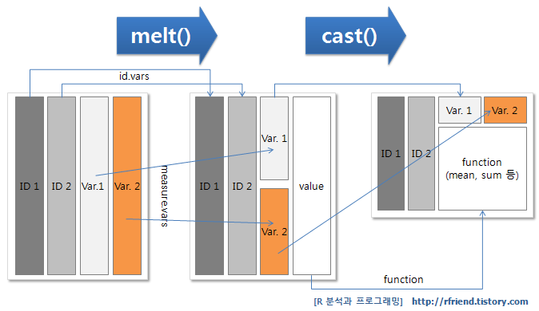

melt and dcast

실습으로 수축기/이완기 혈압 변수를 합쳐서 아래로 내려보자.

```r
library(reshape2)
long <- melt(ex1, id = c("EXMD_BZ_YYYY", "RN_INDI"), measure.vars = c("BP_SYS", "BP_DIA"), variable.name = "BP_type", value.name = "BP")
long
```

| EXMD_BZ_YYYY | RN_INDI | BP_type | BP |
| --- | --- | --- | --- |
| 2012 | 306589 | BP_SYS | 123 |
| 2012 | 330466 | BP_SYS | 118 |
| 2012 | 46233 | BP_SYS | 94 |
| 2012 | 776098 | BP_SYS | 116 |
| 2012 | 550255 | BP_SYS | 140 |
| 2012 | 483693 | BP_SYS | 98 |
| 2012 | 716732 | BP_SYS | 120 |
| 2012 | 985972 | BP_SYS | 100 |
| 2012 | 219397 | BP_SYS | 148 |
| 2012 | 849556 | BP_SYS | 117 |

[output cut: 1230 more lines]

**id** 는 유지할 변수, **measure.vars** 는 내릴 변수를 의미하고, **variable.name, value.name** 은 각각 그룹, 값의 변수이름을 의미한다. 이를 원래대로 되돌리려면 `dcast` 를 이용하는데, **“유지할 변수 ~ 펼칠 변수”** 형태로 formula 를 입력한다.

```r
wide <- dcast(long, EXMD_BZ_YYYY + RN_INDI ~ BP_type, value.var = "BP")
head(wide)
```

| EXMD_BZ_YYYY | RN_INDI | BP_SYS | BP_DIA |
| --- | --- | --- | --- |
| 2012 | 2270 | 113 | 74 |
| 2012 | 4263 | 110 | 75 |
| 2012 | 7386 | 126 | 75 |
| 2012 | 27226 | 110 | 70 |
| 2012 | 27490 | 160 | 90 |
| 2012 | 38967 | 111 | 62 |

### Merge

`merge` 함수를 이용한다. **“by”** 옵션으로 기준이 되는 공통 컬럼을 설정하며, 기준 컬럼의 이름이 두 데이터 셋에서 다른 경우는 **“by.x”** 와 **“by.y”** 로 따로 설정한다. 실습을 위해 **ex1** 데이터를 2개로 나눈 후 `merge` 를 적용하겠다.

```r
ex1.Q <- ex1[, c(1:3, 4:12)]
ex1.measure <- ex1[, c(1:3, 13:ncol(ex1))]
head(ex1.Q)
head(ex1.measure)
```

| EXMD_BZ_YYYY | RN_INDI | HME_YYYYMM | Q_PHX_DX_STK | Q_PHX_DX_HTDZ | Q_PHX_DX_HTN | Q_PHX_DX_DM | Q_PHX_DX_DLD | Q_PHX_DX_PTB | Q_HBV_AG | Q_SMK_YN | Q_DRK_FRQ_V09N |
| --- | --- | --- | --- | --- | --- | --- | --- | --- | --- | --- | --- |
| 2012 | 306589 | 2012-12-01 | 0 | 0 | 0 | 0 | 0 | 0 | 2 | 1 | 0 |
| 2012 | 330466 | 2012-08-01 | 0 | 0 | 0 | 0 | 0 | 1 | 2 | 1 | 0 |
| 2012 | 46233 | 2012-05-01 | 1 | 0 | 0 | 0 | 0 | 0 | 2 | 1 | 0 |
| 2012 | 776098 | 2012-05-01 | 0 | 0 | 0 | 0 | 0 | 0 | 2 | 1 | 0 |
| 2012 | 550255 | 2012-05-01 | 0 | 0 | 0 | 0 | 0 | 0 | 2 | 1 | 0 |
| 2012 | 483693 | 2012-06-01 | 0 | 0 | 0 | 0 | 0 | 0 | 3 | 1 | 0 |

| EXMD_BZ_YYYY | RN_INDI | HME_YYYYMM | HGHT | WGHT | WSTC | BMI | VA_LT | VA_RT | BP_SYS | BP_DIA | URN_PROT | HGB | FBS | TOT_CHOL | TG | HDL | LDL | CRTN | SGOT | SGPT | GGT | GFR | zero | BMI_cat |
| --- | --- | --- | --- | --- | --- | --- | --- | --- | --- | --- | --- | --- | --- | --- | --- | --- | --- | --- | --- | --- | --- | --- | --- | --- |
| 2012 | 306589 | 2012-12-01 | 163 | 63 | 76 | 23.7 | 1.0 | 0.9 | 123 | 80 | 1 | 12.8 | 107 | 188 | 180 | 47 | 104 | 0.9 | 24 | 24 | 25 | 69 | 0 | 0 |
| 2012 | 330466 | 2012-08-01 | 159 | 65 | 87 | 25.7 | 0.9 | 1.0 | 118 | 81 | 1 | 12.3 | 89 | 181 | 73 | 45 | 121 | 0.7 | 20 | 17 | 17 | 94 | 0 | 1 |
| 2012 | 46233 | 2012-05-01 | 140 | 46 | 79 | 23.5 | 0.4 | 0.4 | 94 | 60 | 1 | 13.0 | 99 | 239 | 134 | 65 | 147 | 0.5 | 25 | 28 | 30 | 119 | 0 | 0 |
| 2012 | 776098 | 2012-05-01 | 176 | 78 | 87 | 25.2 | 1.2 | 1.0 | 116 | 86 | 1 | 17.3 | 110 | 213 | 79 | 64 | 133 | 1.0 | 17 | 19 | 32 | 91 | 0 | 1 |
| 2012 | 550255 | 2012-05-01 | 183 | 95 | 92 | 28.4 | 0.5 | 0.5 | 140 | 90 | 1 | 15.1 | 84 | 235 | 165 | 41 | 157 | 1.0 | 19 | 8 | 47 | 87 | 0 | 1 |
| 2012 | 483693 | 2012-06-01 | 158 | 54 | 63 | 21.6 | 1.2 | 1.2 | 98 | 66 | 1 | 13.0 | 72 | 199 | 31 | 64 | 129 | 0.8 | 20 | 15 | 14 | 94 | 0 | 0 |

전자는 설문조사 결과를, 후자는 측정값을 포함했고 **“년도, ID, 검진년월”** 은 공통변수이다. 이 공통변수로 `merge` 를 적용하면

```r
ex1.merge <- merge(ex1.Q, ex1.measure, by = c("EXMD_BZ_YYYY", "RN_INDI", "HME_YYYYMM"), all = T)
head(ex1.merge)
```

| EXMD_BZ_YYYY | RN_INDI | HME_YYYYMM | Q_PHX_DX_STK | Q_PHX_DX_HTDZ | Q_PHX_DX_HTN | Q_PHX_DX_DM | Q_PHX_DX_DLD | Q_PHX_DX_PTB | Q_HBV_AG | Q_SMK_YN | Q_DRK_FRQ_V09N | HGHT | WGHT | WSTC | BMI | VA_LT | VA_RT | BP_SYS | BP_DIA | URN_PROT | HGB | FBS | TOT_CHOL | TG | HDL | LDL | CRTN | SGOT | SGPT | … |
| --- | --- | --- | --- | --- | --- | --- | --- | --- | --- | --- | --- | --- | --- | --- | --- | --- | --- | --- | --- | --- | --- | --- | --- | --- | --- | --- | --- | --- | --- | --- |
| 2012 | 1009573 | 2012-03-01 | 0 | 0 | 0 | 0 | 0 | 1 | 2 | 2 | 1 | 169 | 75 | 87 | 26.3 | 1.2 | 1.2 | 115 | 82 | 1 | 14.2 | 97 | 237 | 215 | 38 | 156 | 1.2 | 22 | 21 | … |
| 2012 | 1010623 | 2012-11-01 | 0 | 0 | 0 | 0 | 0 | 0 | 3 | 3 | 0 | 171 | 82 | 93 | 28.0 | 0.3 | 0.1 | 120 | 70 | 1 | 15.7 | 103 | 205 | 297 | 50 | 95 | 1.3 | 24 | 20 | … |
| 2012 | 107142 | 2012-07-01 | 0 | 0 | 0 | 0 | 0 | 0 | 3 | 3 | 2 | 182 | 76 | 79 | 22.9 | 0.4 | 0.5 | 119 | 70 | 1 | 16.1 | 85 | 196 | 125 | 77 | 94 | 1.0 | 16 | 11 | … |
| 2012 | 115809 | 2012-09-01 | 0 | 0 | 0 | 0 | 0 | 0 | 3 | 3 | 1 | 188 | 111 | 107 | 31.4 | 0.6 | 0.9 | 130 | 82 | 1 | 14.9 | 93 | 172 | 63 | 49 | 110 | 0.9 | 33 | 17 | … |
| 2012 | 122296 | 2012-06-01 | 0 | 0 | 0 | 0 | 0 | 0 | 1 | 1 | 7 | 153 | 47 | 65 | 20.1 | 0.2 | 0.2 | 114 | 86 | 1 | 12.6 | 86 | 169 | 83 | 63 | 89 | 0.9 | 16 | 9 | … |
| 2012 | 122776 | 2012-08-01 | 0 | 0 | 0 | 0 | 0 | 0 | 1 | 2 | 2 | 179 | 72 | 83 | 22.5 | 1.5 | 0.8 | 120 | 80 | 1 | 14.9 | 113 | 150 | 467 | 33 | 44 | 1.0 | 22 | 24 | … |

합쳐진 원래 데이터를 얻을 수 있다. `all = T` 는 한 쪽에만 있는 샘플을 유지하는 옵션이며 빈 변수는 `NA` 로 채워진다. 공통인 샘플만 취하려면 `all = F` 로 바꾸자.

## 마치며

이번 강의를 정리하자.

1. [RStudio cloud](https://rstudio.cloud/) 로 클라우드 환경에서 실습을 진행했으며
2. 기초 벡터연산과 `for`, `if`, `ifelse`, `함수만들기`, `apply` 문을 통해 기본 문법을 익혔고
3. 공단 검진 데이터를 실습자료를 읽어와 데이터를 살펴보는 법을 배웠다.
   - 변수 생성, 클래스 설정, 결측치 처리, 서브데이터, 그룹별 통계, 정렬
4. 마지막으로 Long/wide type 데이터 변환과 `merge` 를 다루었다.

기타 기본적으로 알아야 할 **R** 명령어는 아래의 [Base R Cheat Sheet](https://rstudio.com/wp-content/uploads/2016/10/r-cheat-sheet-3.pdf) 에서 확인할 수 있다.

[figure not shown]

다음 강의에서는 쉬운 문법으로 **R** 의 대세가 된 **[tidyverse](https://www.tidyverse.org/)** 를 다룰 예정인데, 오늘 배운 기본 문법과 많은 비교가 될 것이다. 미리 알아보고 싶은 분은 **[본 블로그의 이전 글](https://blog.zarathu.com/posts/2019-01-03-rdatamanagement/)[^4]** 을 참고하기 바란다.

[^1]: https://jinseob2kim.github.io/rbasic.html
[^2]: https://jinseob2kim.github.io/radv1.html
[^3]: https://t1.daumcdn.net/cfile/tistory/2433F13D55E1163907
[^4]: https://blog.zarathu.com/posts/2019-01-03-rdatamanagement